# Exploratory Data Analysis of the Abalone Dataset

Author

Christy Lee

# Introduction

The Abalone data set provides a fascinating opportunity to predict the age of abalone from physical measurements (Nash et al. 1995).

# Data Overview

The data set consists of several variables, with the target variable being “Rings,” which indicates the abalone’s age. The independent variables include both physical measurements and the sex of the abalone, as detailed below:

- **Sex:** Categorical variable indicating male, female, or infant
- **Length:** Continuous variable measured in millimeters
- **Diameter:** Continuous variable measured in millimeters
- **Height:** Continuous variable measured in millimeters
- **Whole weight:** Total weight of the abalone in grams
- **Shucked weight:** Weight of the meat in grams
- **Viscera weight:** Gut weight after bleeding in grams
- **Shell weight:** Weight of the dried shell in grams

Upon importing the data, the column names were renamed to enhance readability and facilitate easier analysis. Below is a snapshot of the abalone data set:

```r
abalone = read.csv("data/abalone.data", header = FALSE)
colnames(abalone) = c("Sex", "Length", "Diameter", "Height", "Whole_weight", "Shucked_weight", "Viscera_weight", "Shell_weight", "Rings")
head(abalone)
```

```
  Sex Length Diameter Height Whole_weight Shucked_weight Viscera_weight
1   M  0.455    0.365  0.095       0.5140         0.2245         0.1010
2   M  0.350    0.265  0.090       0.2255         0.0995         0.0485
3   F  0.530    0.420  0.135       0.6770         0.2565         0.1415
4   M  0.440    0.365  0.125       0.5160         0.2155         0.1140
5   I  0.330    0.255  0.080       0.2050         0.0895         0.0395
6   I  0.425    0.300  0.095       0.3515         0.1410         0.0775
  Shell_weight Rings
1        0.150    15
2        0.070     7
3        0.210     9
4        0.155    10
5        0.055     7
6        0.120     8
```

## Data Cleaning and Preparation

An initial assessment for missing values was performed, confirming that there is a consistent number of observations with no missing data.

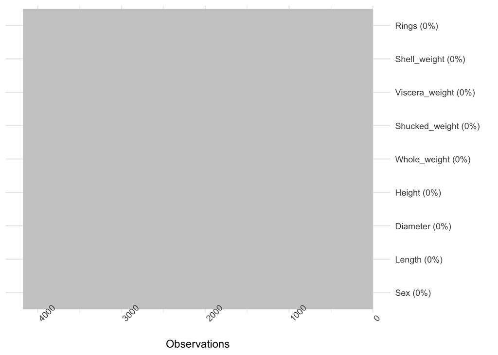

```r
library(tidyverse)
theme_set(theme_bw())
visdat::vis_miss(abalone) + coord_flip() + theme(legend.position = "none")
```